# Practical Machine Learning Course Project

Yifan XIA

23 Sep 2017

## Introduction

```r
library(caret)
library(parallel)
library(doMC)
registerDoMC(cores = detectCores()-1)
set.seed(1234)
```

```r
quiz.testing <- read.csv('pml-testing.csv')
pmlTraining <- read.csv('pml-training.csv')
str(quiz.testing);str(pmlTraining)
```

[output not shown]

A quick look into both datasets leads to the following observations:  
1. Many features in both training and test sets contains only missing values *NA*;  
2. Not all features in the training set are not contained in the test set;  
3. Some features in the training set are mistakenly considered as “factor” while they should be of “numeric” type (*e.g.* kurtosis_roll_arm) and contain many missing values. The 1st and 2nd observations suggest that we must preprocess so that both datasets has the same features (except the *classe*). Afterwards, if any features described in the 3rd observation remain, than we need to find out strategies for missing value imputation (knn, etc.). Meanwhile, some descriptive and time-recording features, *i.e.* user_name and cvtd_timestamp, should be excluded from datasets.

```r
noNaTest <- colnames(quiz.testing)[colSums(is.na(quiz.testing))==0]
uselessFeats <- c('user_name','raw_timestamp_part_1','raw_timestamp_part_2','cvtd_timestamp','X','new_window','num_window')
usefulFeats <- setdiff(noNaTest, uselessFeats)
quiz.testing <- quiz.testing[, usefulFeats]
pmlTraining <- pmlTraining[, c(usefulFeats[-length(usefulFeats)], 'classe')]
str(pmlTraining)
```

```
## 'data.frame':    19622 obs. of  53 variables:
##  $ roll_belt           : num  1.41 1.41 1.42 1.48 1.48 1.45 1.42 1.42 1.43 1.45 ...
##  $ pitch_belt          : num  8.07 8.07 8.07 8.05 8.07 8.06 8.09 8.13 8.16 8.17 ...
##  $ yaw_belt            : num  -94.4 -94.4 -94.4 -94.4 -94.4 -94.4 -94.4 -94.4 -94.4 -94.4 ...
##  $ total_accel_belt    : int  3 3 3 3 3 3 3 3 3 3 ...
##  $ gyros_belt_x        : num  0 0.02 0 0.02 0.02 0.02 0.02 0.02 0.02 0.03 ...
##  $ gyros_belt_y        : num  0 0 0 0 0.02 0 0 0 0 0 ...
##  $ gyros_belt_z        : num  -0.02 -0.02 -0.02 -0.03 -0.02 -0.02 -0.02 -0.02 -0.02 0 ...
##  $ accel_belt_x        : int  -21 -22 -20 -22 -21 -21 -22 -22 -20 -21 ...
##  $ accel_belt_y        : int  4 4 5 3 2 4 3 4 2 4 ...
##  $ accel_belt_z        : int  22 22 23 21 24 21 21 21 24 22 ...
##  $ magnet_belt_x       : int  -3 -7 -2 -6 -6 0 -4 -2 1 -3 ...
##  $ magnet_belt_y       : int  599 608 600 604 600 603 599 603 602 609 ...
##  $ magnet_belt_z       : int  -313 -311 -305 -310 -302 -312 -311 -313 -312 -308 ...
##  $ roll_arm            : num  -128 -128 -128 -128 -128 -128 -128 -128 -128 -128 ...
```

[output cut: 39 more lines]

As the test set is only used for the quiz, it does not have the *classe* feature, and therefore cannot be used for any out-of-sample validation. Thus it is still necessary to split the training set into a REAL training set and a test set for validation.

```r
inTrain <- createDataPartition(pmlTraining$classe, p=0.7, list = FALSE)
training <- pmlTraining[inTrain,]
testing <- pmlTraining[-inTrain,]
str(training)
```

```
## 'data.frame':    13737 obs. of  53 variables:
##  $ roll_belt           : num  1.41 1.42 1.48 1.48 1.45 1.42 1.42 1.43 1.45 1.45 ...
##  $ pitch_belt          : num  8.07 8.07 8.05 8.07 8.06 8.09 8.13 8.16 8.17 8.18 ...
##  $ yaw_belt            : num  -94.4 -94.4 -94.4 -94.4 -94.4 -94.4 -94.4 -94.4 -94.4 -94.4 ...
##  $ total_accel_belt    : int  3 3 3 3 3 3 3 3 3 3 ...
##  $ gyros_belt_x        : num  0.02 0 0.02 0.02 0.02 0.02 0.02 0.02 0.03 0.03 ...
##  $ gyros_belt_y        : num  0 0 0 0.02 0 0 0 0 0 0 ...
##  $ gyros_belt_z        : num  -0.02 -0.02 -0.03 -0.02 -0.02 -0.02 -0.02 -0.02 0 -0.02 ...
##  $ accel_belt_x        : int  -22 -20 -22 -21 -21 -22 -22 -20 -21 -21 ...
##  $ accel_belt_y        : int  4 5 3 2 4 3 4 2 4 2 ...
##  $ accel_belt_z        : int  22 23 21 24 21 21 21 24 22 23 ...
##  $ magnet_belt_x       : int  -7 -2 -6 -6 0 -4 -2 1 -3 -5 ...
##  $ magnet_belt_y       : int  608 600 604 600 603 599 603 602 609 596 ...
##  $ magnet_belt_z       : int  -311 -305 -310 -302 -312 -311 -313 -312 -308 -317 ...
##  $ roll_arm            : num  -128 -128 -128 -128 -128 -128 -128 -128 -128 -128 ...
```

[output cut: 39 more lines]

## Feature selection

Our goal in this part is to select the most relevant and informative features to train the prediction model. We use a criterion based on correlation.

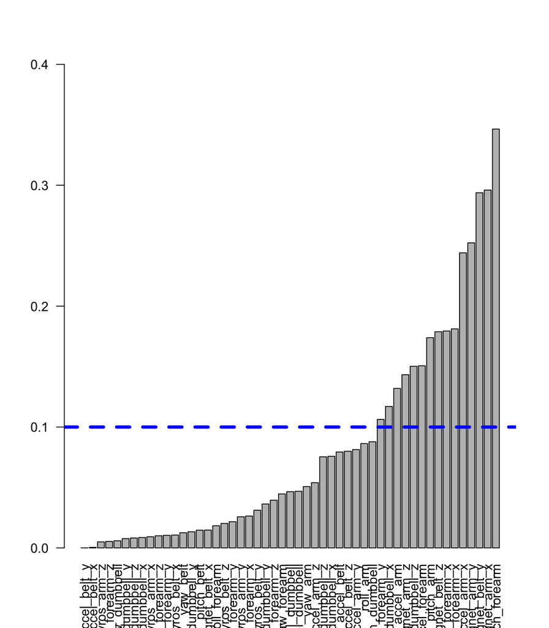

```r
corTrain <- c()
for(i in 2:(length(training)-1)){
        corTrain <- c(corTrain, cor(as.numeric(training$classe),
                                    as.numeric(training[,i])))
}
names(corTrain) <- colnames(training)[2:(length(training)-1)]
barplot(sort(abs(corTrain)), las = 2, ylim = c(0,0.4))
abline(0.1, 0, lty = 'dashed', lwd = 4, col = 'blue')
```

The above figure show how each feature is correlated with the output. We fix arbitrarily 0.1 as the threshold below which the feature is considered to have a neglectable influence on the output.

```r
selFeat <- names(corTrain)[abs(corTrain)>0.1]
str(training[,selFeat])
```

```
## 'data.frame':    13737 obs. of  15 variables:
##  $ magnet_belt_y      : int  608 600 604 600 603 599 603 602 609 596 ...
##  $ magnet_belt_z      : int  -311 -305 -310 -302 -312 -311 -313 -312 -308 -317 ...
##  $ pitch_arm          : num  22.5 22.5 22.1 22.1 22 21.9 21.8 21.7 21.6 21.5 ...
##  $ total_accel_arm    : int  34 34 34 34 34 34 34 34 34 34 ...
##  $ accel_arm_x        : int  -290 -289 -289 -289 -289 -289 -289 -288 -288 -290 ...
##  $ magnet_arm_x       : int  -369 -368 -372 -374 -369 -373 -372 -369 -376 -366 ...
##  $ magnet_arm_y       : int  337 344 344 337 342 336 338 341 334 339 ...
##  $ magnet_arm_z       : int  513 513 512 506 513 509 510 518 516 509 ...
##  $ accel_dumbbell_x   : int  -233 -232 -232 -233 -234 -232 -234 -232 -235 -233 ...
##  $ magnet_dumbbell_z  : num  -64 -63 -60 -68 -66 -70 -74 -65 -69 -64 ...
##  $ pitch_forearm      : num  -63.9 -63.9 -63.9 -63.9 -63.9 -63.9 -63.8 -63.8 -63.8 -63.8 ...
##  $ total_accel_forearm: int  36 36 36 36 36 36 36 36 36 36 ...
##  $ accel_forearm_x    : int  192 196 189 189 193 195 193 193 190 193 ...
##  $ magnet_forearm_x   : int  -18 -18 -16 -17 -9 -18 -9 -16 -22 -17 ...
##  $ magnet_forearm_y   : num  661 658 658 655 660 659 660 653 656 657 ...
```

We hence obtaine 15 features based on which we will train the prediction model.

## Machine Learning

We first build the training formula by the following:

```r
trainFormula <- paste('classe', paste(selFeat, collapse = '+'), sep = '~')
```

As we have a classification problem with multiple outputs (more than two), we fit a ** Random Forest** model to the training set with a 10-fold cross-validation.

```r
rfControl <- trainControl(method = 'cv', number = 10)
modelRf <- train(as.formula(trainFormula), data = training, method = 'rf', ntree = 500, trControl = rfControl)
modelRf
```

```
## Random Forest
##
## 13737 samples
##    15 predictor
##     5 classes: 'A', 'B', 'C', 'D', 'E'
##
## No pre-processing
## Resampling: Cross-Validated (10 fold)
## Summary of sample sizes: 12362, 12364, 12362, 12363, 12362, 12364, ...
## Resampling results across tuning parameters:
##
##   mtry  Accuracy   Kappa
##    2    0.9582129  0.9471214
##    8    0.9588691  0.9479600
##   15    0.9512262  0.9382835
##
## Accuracy was used to select the optimal model using  the largest value.
## The final value used for the model was mtry = 8.
```

The RF model is then applied on the testing set:

```r
predClass <- predict(modelRf, testing)
confusionMatrix(testing$classe, predClass)
```

```
## Confusion Matrix and Statistics
##
##           Reference
## Prediction    A    B    C    D    E
##          A 1644   17    2   10    1
##          B   34 1079   14    8    4
##          C    1   16  990   15    4
##          D    4    9   46  901    4
##          E    2   14   11   23 1032
##
## Overall Statistics
##
##                Accuracy : 0.9594
##                  95% CI : (0.954, 0.9643)
##     No Information Rate : 0.2863
##     P-Value [Acc > NIR] : < 2.2e-16
##
##                   Kappa : 0.9486
##  Mcnemar's Test P-Value : 9.272e-07
##
## Statistics by Class:
##
##                      Class: A Class: B Class: C Class: D Class: E
## Sensitivity            0.9757   0.9507   0.9313   0.9415   0.9876
## Specificity            0.9929   0.9874   0.9925   0.9872   0.9897
## Pos Pred Value         0.9821   0.9473   0.9649   0.9346   0.9538
## Neg Pred Value         0.9903   0.9882   0.9850   0.9886   0.9973
## Prevalence             0.2863   0.1929   0.1806   0.1626   0.1776
## Detection Rate         0.2794   0.1833   0.1682   0.1531   0.1754
## Detection Prevalence   0.2845   0.1935   0.1743   0.1638   0.1839
## Balanced Accuracy      0.9843   0.9690   0.9619   0.9643   0.9886
```

```r
accuracy <- postResample(predClass, testing$classe)
accuracy
```

```
##  Accuracy     Kappa
## 0.9593883 0.9486221
```

```r
oose <- 1-accuracy[1]
names(oose)<-c('Out-of-sample Error')
oose
```

```
## Out-of-sample Error
##          0.04061172
```

## Predicting the quiz test data

```r
quiz.pred <- predict(modelRf, quiz.testing)
quiz.pred
```

```
##  [1] B A B A A E D D A A B C B A E E A B B B
## Levels: A B C D E
```